# MULTIVARIATE ANALYSIS – H1B VISA DATA – Exploratory Data Analysis (EDA)

Ashita Shetty

### Loading the data

```r
library(readr)
h1b <- read_csv("C:\\Users\\Dell\\Desktop\\RBS\\Semester II\\Multivariate Analysis\\Assignment\\data\\H1_B-2014.csv")
str(h1b)
```

```
## spc_tbl_ [19,996 x 30] (S3: spec_tbl_df/tbl_df/tbl/data.frame)
##  $ LCA_CASE_NUMBER               : chr [1:19996] "I-200-14209-794540" "I-200-13182-969853" "I-200-14076-109575" "I-200-14232-447516" ...
##  $ STATUS                        : chr [1:19996] "CERTIFIED" "CERTIFIED" "CERTIFIED" "CERTIFIED" ...
##  $ LCA_CASE_SUBMIT               : chr [1:19996] "29-07-2014 14:48" "08-04-2014 11:57" "17-03-2014 18:37" "20-08-2014 22:13" ...
##  $ DECISION_DATE                 : chr [1:19996] "04-08-2014 22:01" "14-04-2014 22:01" "21-03-2014 23:11" "27-08-2014 22:01" ...
##  $ APP_DIFF                      : num [1:19996] 0.21 0.21 0.14 0.23 0.22 ...
##  $ VISA_CLASS                    : chr [1:19996] "H-1B" "H-1B" "H-1B" "H-1B" ...
##  $ LCA_CASE_EMPLOYMENT_START_DATE: chr [1:19996] "15-08-2014" "14-04-2014" "16-09-2014" "01-10-2014" ...
##  $ LCA_CASE_EMPLOYMENT_END_DATE  : chr [1:19996] "14-08-2017" "13-04-2017" "16-09-2017" "30-09-2017" ...
##  $ EMP_DIFF                      : num [1:19996] 36.5 36.5 36.5 36.5 36.5 ...
##  $ LCA_CASE_EMPLOYER_NAME        : chr [1:19996] "DJI TECHNOLOGY LLC" "VEDICSOFT" "SRT IT INCORPORATED" "SYSFORE TECHNOLOGIES, INC." ...
##  $ LCA_CASE_EMPLOYER_ADDRESS     : chr [1:19996] "6424 SANTA MONICA BLVD." "100 WOOD AVENUE SOUTH" "1999 WABASH AVENUE" "11465 JOHNS CREEK PARKWAY" ...
##  $ LCA_CASE_EMPLOYER_CITY        : chr [1:19996] "SANTA MONICA" "ISELIN" "SPRINGFIELD" "JOHNS CREEK" ...
##  $ LCA_CASE_EMPLOYER_STATE       : chr [1:19996] "CA" "NJ" "IL" "GA" ...
##  $ LCA_CASE_EMPLOYER_POSTAL_CODE : num [1:19996] 90404 8830 62704 30097 60064 ...
##  $ LCA_CASE_SOC_CODE             : chr [1:19996] "11-1011" "15-1132" "15-1132" "15-1131" ...
##  $ LCA_CASE_SOC_NAME             : chr [1:19996] "Chief Executives" "Software Developers, Applications" "Software Developers, Applications" "Computer Programmers" ...
##  $ LCA_CASE_JOB_TITLE            : chr [1:19996] "CHIEF EXECUTIVE" "INFORMATICA DEVELOPER" "SOFTWARE DEVELOPER" "PROGRAMMER ANALYST" ...
##  $ LCA_CASE_WAGE_RATE_FROM       : num [1:19996] 120000 63294 65000 75000 97710 ...
##  $ LCA_CASE_WAGE_RATE_TO         : num [1:19996] 220000 NA NA NA NA NA 185000 NA 90000 NA ...
##  $ LCA_CASE_WAGE_RATE_UNIT       : chr [1:19996] "Year" "Year" "Year" "Year" ...
##  $ FULL_TIME_POS                 : chr [1:19996] "Y" "Y" "Y" "Y" ...
##  $ TOTAL_WORKERS                 : num [1:19996] 1 1 1 1 1 1 1 1 1 1 ...
##  $ LCA_CASE_WORKLOC1_CITY        : chr [1:19996] "LOS ANGELES" "ST LOUIS" "RICHARDSON" "RICHFIELD" ...
##  $ LCA_CASE_WORKLOC1_STATE       : chr [1:19996] "CA" "MO" "MO" "MN" ...
##  $ PW_1                          : num [1:19996] 119288 63294 62379 65416 67621 ...
##  $ PW_UNIT_1                     : chr [1:19996] "Year" "Year" "Year" "Year" ...
##  $ PW_SOURCE_1                   : chr [1:19996] "OES" "Other" "OES" "OES" ...
##  $ OTHER_WAGE_SOURCE_1           : chr [1:19996] "OFLC ONLINE DATA CENTER" "OFLC ONLINE DATA CENTER" "OFLC ONLINE DATA CENTER" "OFLC ONLINE DATACENTER" ...
##  $ YR_SOURCE_PUB_1               : num [1:19996] 2014 2014 2013 2014 2014 ...
##  $ LCA_CASE_NAICS_CODE           : num [1:19996] 541990 541511 541511 541511 3254 ...
##  - attr(*, "spec")=
##   .. cols(
##   ..   LCA_CASE_NUMBER = col_character(),
##   ..   STATUS = col_character(),
##   ..   LCA_CASE_SUBMIT = col_character(),
##   ..   DECISION_DATE = col_character(),
##   ..   APP_DIFF = col_double(),
##   ..   VISA_CLASS = col_character(),
##   ..   LCA_CASE_EMPLOYMENT_START_DATE = col_character(),
```

[output cut: 10 more lines]

```
##   ..   LCA_CASE_WAGE_RATE_FROM = col_double(),
##   ..   LCA_CASE_WAGE_RATE_TO = col_double(),
##   ..   LCA_CASE_WAGE_RATE_UNIT = col_character(),
##   ..   FULL_TIME_POS = col_character(),
##   ..   TOTAL_WORKERS = col_double(),
##   ..   LCA_CASE_WORKLOC1_CITY = col_character(),
##   ..   LCA_CASE_WORKLOC1_STATE = col_character(),
##   ..   PW_1 = col_double(),
##   ..   PW_UNIT_1 = col_character(),
##   ..   PW_SOURCE_1 = col_character(),
##   ..   OTHER_WAGE_SOURCE_1 = col_character(),
##   ..   YR_SOURCE_PUB_1 = col_double(),
##   ..   LCA_CASE_NAICS_CODE = col_double()
##   .. )
##  - attr(*, "problems")=<externalptr>
```

### Loading packages

```r
library(lattice)
library(ggplot2)
library(ggridges)
library(ggvis)
library(ggthemes)
library(cowplot)
library(gapminder)
library(gganimate)
library(dplyr)
library(tidyverse)
library(grid)
library(gridExtra)
library(RColorBrewer)
options(scipen=999)
```

### EDA

##### **1. What is the distribution of visa applicant status?**

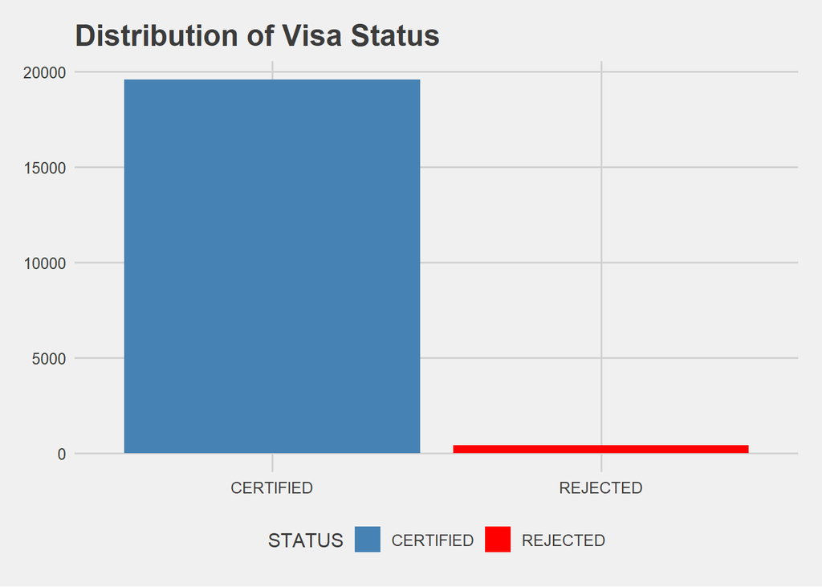

```r
ggplot(h1b, aes(x = STATUS, fill = STATUS)) +
  geom_bar() +
  labs(title = "Distribution of Visa Status",
       x = "Status",
       y = "Count") +
  scale_fill_manual(values = c("CERTIFIED" = "steelblue", "REJECTED" = "red"))+
  theme_fivethirtyeight()
```

##### **Inference:**

It can be observed that *majority of the applicants have been approved of their visa application status*.

##### **2. What is the distribution of Visa Classes based on their approval status?**

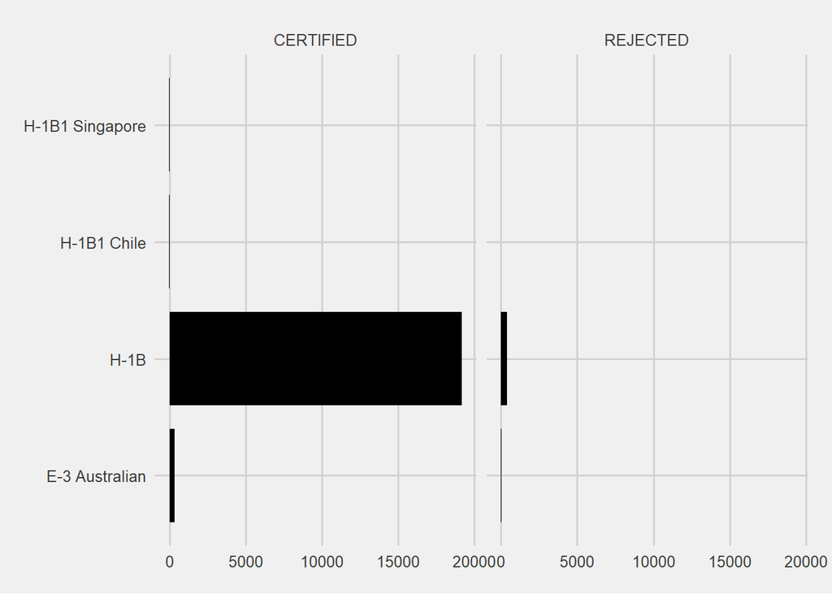

```r
ggplot(h1b, aes(VISA_CLASS)) + facet_grid(.~STATUS) +
  geom_bar(fill="black", position="stack", width = 0.8) + coord_flip()+ theme_fivethirtyeight()
```

##### **Inference:**

- The analysis suggests that the majority of applicants opted for H1B, with E-3 Australian being the next popular choice.
- Notably, **H1B** stands out as having the highest number of certifications, indicating a predominantly positive status.

##### **3. Try to understand the Wage rate for case applicants, and dig further into the segregation based on Visa applied for**

```r
summary(h1b$LCA_CASE_WAGE_RATE_FROM)
```

```
##     Min.  1st Qu.   Median     Mean  3rd Qu.     Max.
##      8.5  60000.0  70000.0  75439.8  90000.0 825000.0
```

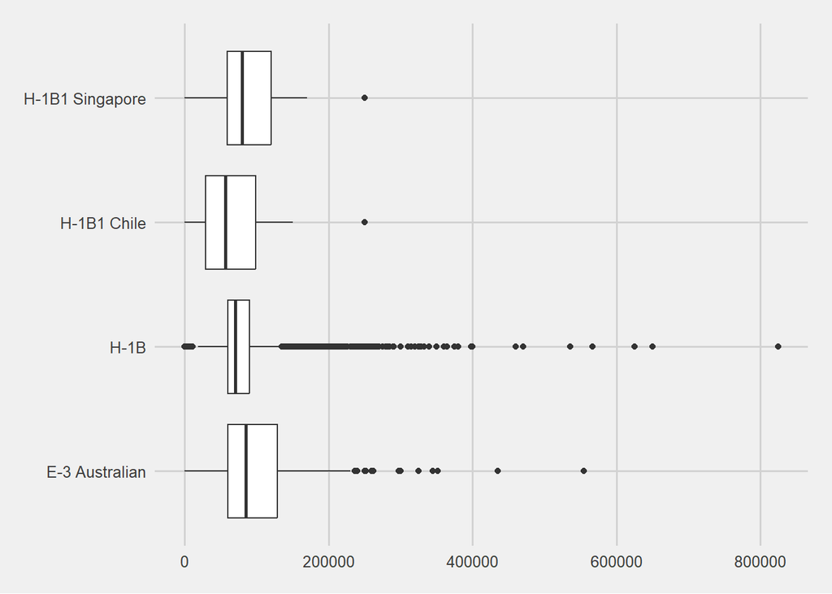

```r
ggplot(h1b, aes(x = VISA_CLASS, y = LCA_CASE_WAGE_RATE_FROM)) +
  geom_boxplot() + coord_flip()+
  theme_fivethirtyeight()
```

##### **Inference:**

- The evidence demonstrates that the median amounts for most visa types are approximately within a similar range.
- However, an outlier is noticeable in the H-1B visa type, where the maximum value exceeds 800,000.

##### **4. What is the trend in the decision period and is there a pattern to be observed that exposes when most decisions are usually out?**

```r
library(lubridate)
# Convert DECISION_DATE to a datetime object
h1b$DECISION_DATE <- dmy_hm(h1b$DECISION_DATE)

# Extract year and month from the datetime
h1b <- h1b %>% mutate(YearMonth = format(DECISION_DATE, "%Y-%m"))
```

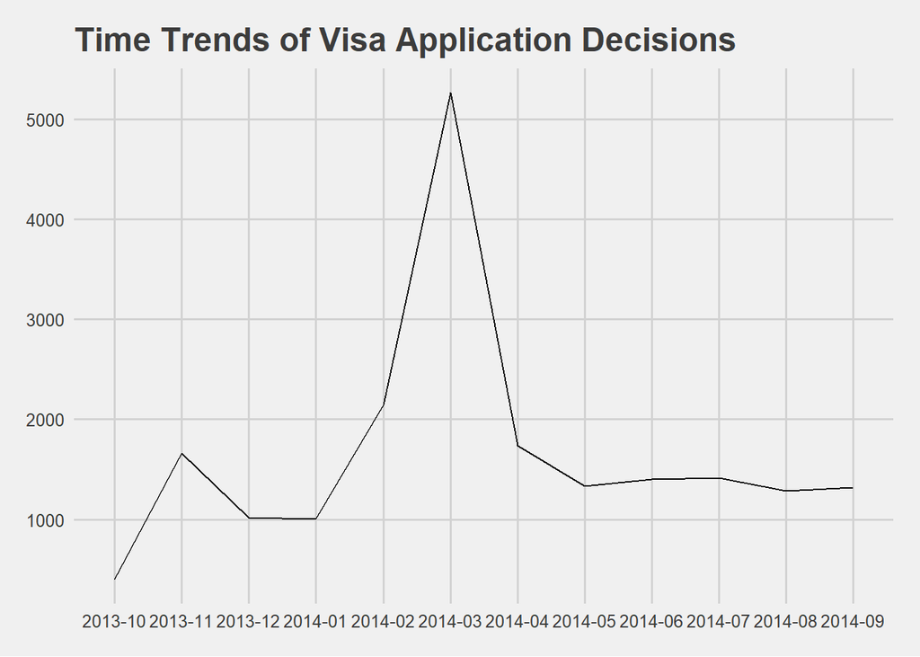

```r
ggplot(h1b, aes(x = YearMonth, group = 1)) +
  geom_line(stat = "count") +
  labs(title = "Time Trends of Visa Application Decisions", x = "Year-Month",y = "Number of Visa Applications")+
  theme_fivethirtyeight()
```

##### **Inference:**

- It is noticeable that the majority of results were announced in March for the year 2014.
- Following March, there was a significant decrease, averaging around 1,500, which was also observed before March.

##### **5. What are the 5 Most Common Job titles for H1B Visa Holders?**

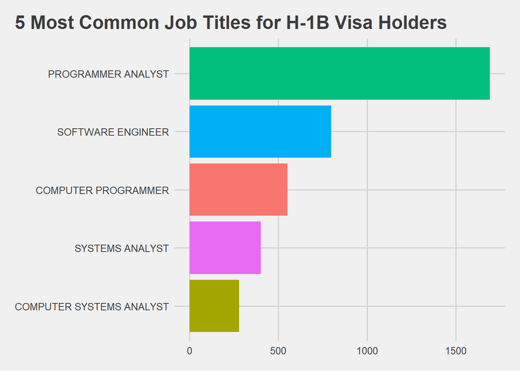

```r
h1b %>%
  count(LCA_CASE_JOB_TITLE) %>%
  top_n(5, n) %>%
  ggplot(aes(x = reorder(LCA_CASE_JOB_TITLE, n), y = n, fill = LCA_CASE_JOB_TITLE)) +
  geom_bar(stat = "identity") +
  labs(title = "5 Most Common Job Titles for H-1B Visa Holders",
       x = "Job Title",
       y = "Frequency") +
  theme_fivethirtyeight() + coord_flip()+ theme(legend.position = "none", plot.title.position = "plot")
```

```r
options(repr.plot.width = 50)
```

##### **Inference:**

- The visual features the top 5 job roles of H1B Visa Holders.
- **Programmer Analyst is a clear winner in this!**

##### **6. Comparison between Wage Rates & Prevailing Wage**

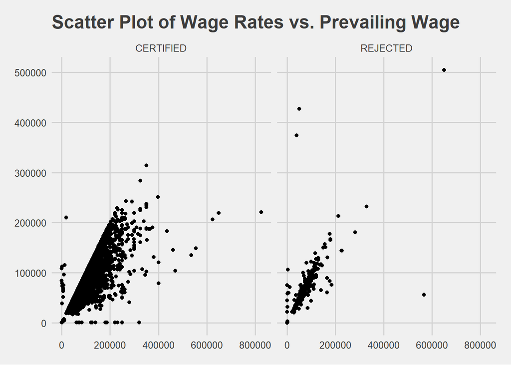

```r
ggplot(h1b, aes(x = LCA_CASE_WAGE_RATE_FROM, y = PW_1)) +
  facet_wrap(.~STATUS)+
  geom_point() +
  labs(title = "Scatter Plot of Wage Rates vs. Prevailing Wage",
       x = "Wage Rate (From)",
       y = "Prevailing Wage") +
  theme_fivethirtyeight()
```

##### **Inference:**

- The examination of the scatter plot indicates a robust positive correlation due to the concentrated grouping of most points along a rising trend.
- Some outliers are observed, particularly in Rejected cases.
- A linear relationship is evident between the two variables.

#### **7. What is the correlation between Numerical columns in the data?**

```r
h1b$WAGE_RATE_FROM <- as.numeric(h1b$LCA_CASE_WAGE_RATE_FROM)
h1b$EMPLOYER_POSTAL_CODE <- as.numeric(h1b$LCA_CASE_EMPLOYER_POSTAL_CODE)
h1b$EMP_DIFF <- as.numeric(h1b$EMP_DIFF)
h1b$APP_DIFF <- as.numeric(h1b$APP_DIFF)
h1b$TOTAL_WORKERS <- as.numeric(h1b$TOTAL_WORKERS)
h1b$YR_SOURCE <- as.numeric(h1b$YR_SOURCE_PUB_1)
h1b$NAICS_CODE <- as.numeric(h1b$LCA_CASE_NAICS_CODE)
```

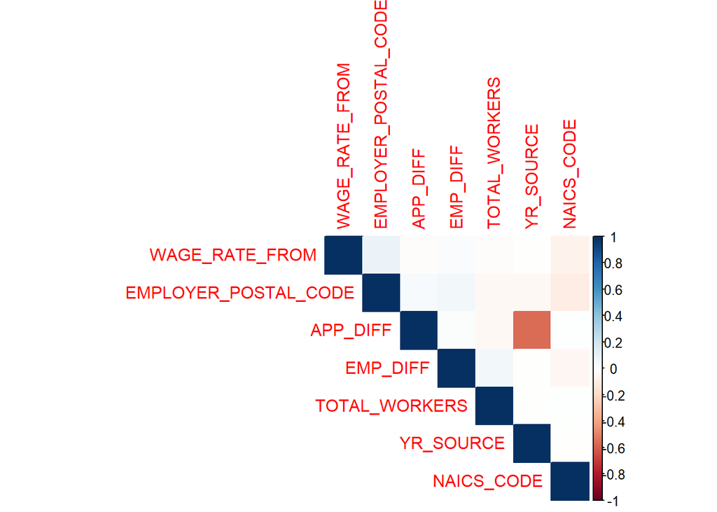

```r
library(corrplot)
cor_matrix <- cor(h1b[, c("WAGE_RATE_FROM", "EMPLOYER_POSTAL_CODE", "APP_DIFF", "EMP_DIFF", "TOTAL_WORKERS", "YR_SOURCE", "NAICS_CODE")])

corrplot(cor_matrix, type = "upper", method = "color")
```

##### **Inference:**

- The majority of these columns exhibit no correlations, with a few displaying subtle positive associations.
- Examples of columns with positive correlations include: Wage rate and employer postal code; Employer Postal Code and the applicant’s tenure in the company; Likewise, the applicant’s tenure in the company and the total number of workers in that specific company.
- There is a negative correlation between the year of introduction of the prevailing wage source (YR_SOURCE) and the time difference between the applicant’s case date and decision date (APP_DIFF).